# Integrated lakefish

October 2023

Last updated: October 20 2023 at 12:43:16.

Loading packages:

```r
#devtools::install_github("PhilipMostert/PointedSDMs")
library(PointedSDMs) # model fitting
library(ggplot2)     # plotting
library(raster)      # ???? Model fitting fails if I exclude this
library(mapproj)     # map options for plotting
library(INLA)        # functions for specifying mesh
library(dplyr)       # data handling
library(sf)          # spatial stuff
library(showtext)    # font for plot
library(patchwork)   # combining figures
```

```r
# Plot settings
showtext_auto()
f1 <- "Open sans"
font_add_google(f1, f1)
```

## Downloading data

Before you run this file, make sure you have the following files:

- `data/artsobs_clean_new.rds`
- `data/survey_clean_new.rds`
- `data/environmental_covariates.rds`
- `data/Norwegian_lakes.rds`

```r
fishes <- c("Salvelinus_alpinus", "Esox_lucius", "Salmo_trutta", "Perca_fluviatilis")
```

## Loading Norway map

We begin by making a spatial mesh out of a map of Norway.

```r
#norway <- ggplot2::map_data("world", region = "Norway(?!:Svalbard)")
#norway <- setdiff(norway, dplyr::filter(norway, subregion == "Jan Mayen"))
#norway_sf <- st_as_sf(norway, coords = c("long", "lat"), crs = proj)

proj <- '+proj=utm +zone=32 +datum=WGS84 +units=m +no_defs'
norwayfill <- maps::map("world", "norway", fill=TRUE, plot=FALSE,
                  ylim=c(58,72), xlim=c(4,32))
IDs <- sapply(strsplit(norwayfill$names, ":"), function(x) x[1])
norway.poly <- maptools::map2SpatialPolygons(norwayfill, IDs = IDs,
                                             proj4string = CRS(proj))
```

```
## Please note that 'maptools' will be retired during October 2023,
## plan transition at your earliest convenience (see
## https://r-spatial.org/r/2023/05/15/evolution4.html and earlier blogs
## for guidance);some functionality will be moved to 'sp'.
##  Checking rgeos availability: FALSE
```

```r
mesh <- inla.mesh.2d(boundary = inla.sp2segment(norway.poly),
                     #cutoff = 0.3, # smallest allowed distance between points
                     max.edge = 1, # increase this for fewer integration points
                     offset = c(0.5, 0.5), # points outside Norway as well
                     #offset = 0.5, # only points inside Norway
                     crs = st_crs(proj))

plot(mesh)
```

The mesh we used for the final results in the paper is quite fine, if you would like to run a faster version for testing purposes it is possible to use a rougher mesh. You can either tweak the above mesh yourself, or try this version:

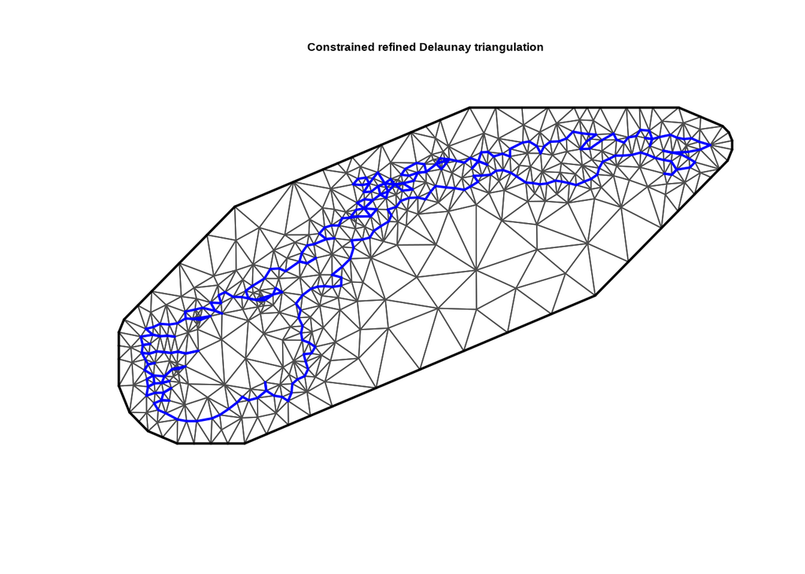

```r
mesh <- inla.mesh.2d(boundary = inla.sp2segment(norway.poly),
                     cutoff = 0.3,
                     max.edge = c(6, 3),
                     offset = c(1, 1),
                     crs = st_crs(proj))
plot(mesh)
```

## Setting up covariate data

Next we load the environmental data, which will be used as covariates.

```r
# Covariates
covariates_raw <- readRDS("data/environmental_covariates.RDS")

covariates <- covariates_raw %>%
  # Log-transform area of lake
  dplyr::mutate(log_area = log(area_km2)) %>%
  # Remove some uninformative variables
  dplyr::select(-c(ebint, no_vatn_lnr, eb_waterregionID))

# Choose from
# "decimalLatitude", "decimalLongitude",
# "log_area", "perimeter_m", "distance_to_road",
# "eurolst_bio10", "catchment_area_km2", "SCI", "HFP"

Use <- c("log_area", "eurolst_bio10", "SCI")

cov_pixel <- SpatialPixelsDataFrame(
  points = covariates[,c("decimalLongitude","decimalLatitude")],
  data = covariates[,Use],
  proj4string = CRS(proj),
  tol = 0.340571)

# Scale covariates and convert to terra::rast
cov_raster <- scale(terra::rast(cov_pixel))
```

## Observation data

For this model, we have two observation sets, one which is downloaded from GBIF and one that is a survey dataset (see separate document for download instructions).

```r
# Observations
survey <- readRDS("data/survey_clean_new.rds") %>%
  filter(species %in% fishes)
artsobs <- readRDS("data/artsobs_clean_new.rds") %>%
  filter(species %in% fishes)
```

We can view the observed data points:

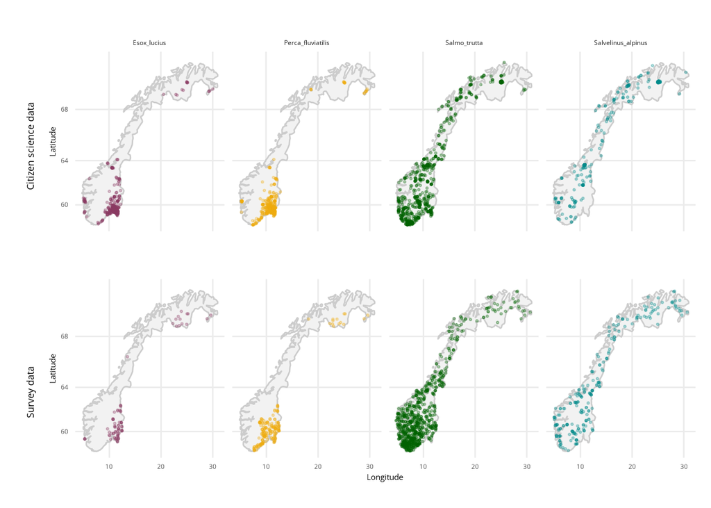

```r
colors_fish <- c("hotpink4", "darkgoldenrod2", "darkgreen", "darkcyan")
norway <- ggplot2::map_data("world", region = "Norway(?!:Svalbard)")
norway <- setdiff(norway, dplyr::filter(norway, subregion == "Jan Mayen"))

p_artsobs <- ggplot(artsobs, aes(x = decimalLongitude, y = decimalLatitude)) +
  geom_polygon(data = norway, aes(long, lat, group = group),
               color="grey80", fill = "grey95") +
  geom_point(aes(color = species), size = 0.5, alpha = 0.3) +
  facet_wrap(~species, nrow = 1) +
  scale_color_manual(values = colors_fish) +
  coord_map() +
  ylab("Latitude") +
  labs(tag = "Citizen science data") +
  theme_minimal() +
  theme(text = element_text(family = f1),
        plot.tag = element_text(angle = 90, hjust = 0.5),
        plot.tag.position = c(-0.03, 0.45),
        legend.position = "none",
        axis.title.x = element_blank(),
        axis.text.x = element_blank())

p_survey <- ggplot(survey %>% filter(occurrenceStatus == 1),
       aes(x = decimalLongitude, y = decimalLatitude)) +
  geom_polygon(data = norway, aes(long, lat, group = group),
               color="grey80", fill = "grey95") +
  geom_jitter(aes(color = species), size = 0.5, alpha = 0.3) +#, width = 0.1, height = 0.1) +
  facet_wrap(~species, nrow = 1) +
  scale_color_manual(values = colors_fish) +
  coord_map() +
  xlab("Longitude") +
  ylab("Latitude") +
  labs(tag = "Survey data") +
  theme_minimal() +
  theme(text = element_text(family = f1),
        plot.tag = element_text(angle = 90, hjust = 0.5),
        plot.tag.position = c(-0.03, 0.45),
        legend.position = "none",
        strip.text = element_blank(),
        plot.margin = margin(l = 30))

p_artsobs / p_survey
```

```r
ggsave("figures/presence_points.pdf", height = 5, width = 8)
```

## Joint model for four fish species

For the presence/absence survey data, we use a Bernoulli distribution, where the presence probability depends on some covariates $x(s)$, along with a spatial field $\xi_{j}(s)$ for species $j\in \{\textit{Salmo trutta, Perca fluvatilis, Esox lucius, Salvelinus alpinus}\}$,
$$\begin{align}
Y_{PA, j}(s_i) &\sim \text{Bernoulli}(p_{PA, j}(s_i)) \\
\text{cloglog}(p_{PA, j}(s_i)) &= \alpha_{PA, j} + x(s_i)^T\beta_j + \xi_{j}(s_i).
\end{align}$$
The presence-only data is fitted with a Poisson point process model, where the intensity depends on the same covariates $x(s)$ and the same spatial field $\xi_{j}(s)$, plus an additional spatial field $\xi_{\text{bias}}(s)$ that is unique to the citizen science data, but shared across all fish species:
$$\begin{align}
Y_{PO, j}(s_i) &\sim \text{Poisson}(e^{\eta_{PO, j}(s_i)}) \\
\eta_{PO, j}(s_i) &= \alpha_{PO, j} + x(s)^T\beta_j + \xi_{j}(s_i) + \xi_{\text{bias}}(s_i).
\end{align}$$
So in summary, for this model we have:

- one bias field, based on CS data and common across all species
- four shared fields, shared across the data sets (survey/citizen science), but separate for each fish species.

Since we have two data sets and four species, that means that we in total have eight sub-models.

We first prepare the model using the `intModel` function.

```r
fish_model_setup <- intModel(
  survey,                              # Survey data
  artsobs,                             # Citizen science data
  spatialCovariates = cov_raster,      # Covariates
  speciesName = "species",             # The column containing species name
  speciesSpatial = "copy",             # Should the species have their own sp. field?
  Coordinates = c("decimalLongitude", "decimalLatitude"), # Names of the coordinate variables
  responsePA = "occurrenceStatus",     # Name of the response column
  pointsSpatial = NULL,              # Use INLA's "copy" feature to create the shared spatial field
  Mesh = mesh,                         # inla mesh object
  Projection = proj)                   # CRS for points and covariates
```

This model has the species specific spatial fields, but we also want a bias field that is shared across the species. We add this using `$addBias`.

```r
# Add bias field (shared across all species)
fish_model_setup$addBias("artsobs")
```

For the species specific fields, the default in PointedSDMs is that these are allowed to be different up to a scaling factor (named beta in INLA) across the data sets. That means that for instance the trout-specific spatial field for the citizen science data set is equal to beta times the trout-specific spatial field for the survey data. In practice, this has to do with the copy-option in INLA. But in our model we want them to be the same, not to vary by a factor. So we manually change this using the `$changeComponents` function, by setting `hyper = list(beta = list(fixed = TRUE))` for each of the four citizen science fields.

```r
# Remove beta (scaling parameter for copied spatial fields)
# Note: The only change to the components here is to make beta = list(fixed = TRUE)
#  instead of FALSE.

fish_model_setup$changeComponents(
  ~ Perca_fluviatilis_artsobs_spatial(
      main = geometry,
      copy = "Perca_fluviatilis_survey_spatial",
      hyper = list(beta = list(fixed = TRUE))) +
    Salmo_trutta_artsobs_spatial(
      main = geometry,
      copy = "Salmo_trutta_survey_spatial",
      hyper = list(beta = list(fixed = TRUE))) +
    Salvelinus_alpinus_artsobs_spatial(
      main = geometry,
      copy = "Salvelinus_alpinus_survey_spatial",
      hyper = list(beta = list(fixed = TRUE))) +
    Esox_lucius_artsobs_spatial(
      main = geometry,
      copy = "Esox_lucius_survey_spatial",
      hyper = list(beta = list(fixed = TRUE))))
```

```
## Components:
## ~-1 + Perca_fluviatilis_survey_spatial(main = geometry, model = Perca_fluviatilis_survey_field) +
##     Salmo_trutta_survey_spatial(main = geometry, model = Salmo_trutta_survey_field) +
##     Salvelinus_alpinus_survey_spatial(main = geometry, model = Salvelinus_alpinus_survey_field) +
##     Esox_lucius_survey_spatial(main = geometry, model = Esox_lucius_survey_field) +
##     Salmo_trutta_artsobs_spatial(main = geometry, copy = "Salmo_trutta_survey_spatial",
##         hyper = list(beta = list(fixed = FALSE))) + Salvelinus_alpinus_artsobs_spatial(main = geometry,
##     copy = "Salvelinus_alpinus_survey_spatial", hyper = list(beta = list(fixed = FALSE))) +
##     Esox_lucius_artsobs_spatial(main = geometry, copy = "Esox_lucius_survey_spatial",
##         hyper = list(beta = list(fixed = FALSE))) + Perca_fluviatilis_log_area(main = Perca_fluviatilis_log_area,
##     model = "linear") + Salmo_trutta_log_area(main = Salmo_trutta_log_area,
##     model = "linear") + Salvelinus_alpinus_log_area(main = Salvelinus_alpinus_log_area,
##     model = "linear") + Esox_lucius_log_area(main = Esox_lucius_log_area,
##     model = "linear") + Perca_fluviatilis_eurolst_bio10(main = Perca_fluviatilis_eurolst_bio10,
##     model = "linear") + Salmo_trutta_eurolst_bio10(main = Salmo_trutta_eurolst_bio10,
##     model = "linear") + Salvelinus_alpinus_eurolst_bio10(main = Salvelinus_alpinus_eurolst_bio10,
##     model = "linear") + Esox_lucius_eurolst_bio10(main = Esox_lucius_eurolst_bio10,
##     model = "linear") + Perca_fluviatilis_SCI(main = Perca_fluviatilis_SCI,
##     model = "linear") + Salmo_trutta_SCI(main = Salmo_trutta_SCI,
##     model = "linear") + Salvelinus_alpinus_SCI(main = Salvelinus_alpinus_SCI,
##     model = "linear") + Esox_lucius_SCI(main = Esox_lucius_SCI,
##     model = "linear") + Perca_fluviatilis_intercept(1) + Salmo_trutta_intercept(1) +
##     Salvelinus_alpinus_intercept(1) + Esox_lucius_intercept(1) +
##     artsobs_biasField(main = geometry, model = artsobs_bias_field) +
##     Perca_fluviatilis_artsobs_spatial(main = geometry, copy = "Perca_fluviatilis_survey_spatial",
##         hyper = list(beta = list(fixed = TRUE))) + Salmo_trutta_artsobs_spatial(main = geometry,
##     copy = "Salmo_trutta_survey_spatial", hyper = list(beta = list(fixed = TRUE))) +
##     Salvelinus_alpinus_artsobs_spatial(main = geometry, copy = "Salvelinus_alpinus_survey_spatial",
##         hyper = list(beta = list(fixed = TRUE))) + Esox_lucius_artsobs_spatial(main = geometry,
##     copy = "Esox_lucius_survey_spatial", hyper = list(beta = list(fixed = TRUE)))
## <environment: 0x562d503e0858>
```

We may look at the components that are included in the model by calling `$changeComponents` with no arguments:

```r
fish_model_setup$changeComponents()
```

```
## Components:
## ~-1 + Perca_fluviatilis_survey_spatial(main = geometry, model = Perca_fluviatilis_survey_field) +
##     Salmo_trutta_survey_spatial(main = geometry, model = Salmo_trutta_survey_field) +
##     Salvelinus_alpinus_survey_spatial(main = geometry, model = Salvelinus_alpinus_survey_field) +
##     Esox_lucius_survey_spatial(main = geometry, model = Esox_lucius_survey_field) +
##     Salmo_trutta_artsobs_spatial(main = geometry, copy = "Salmo_trutta_survey_spatial",
##         hyper = list(beta = list(fixed = FALSE))) + Salvelinus_alpinus_artsobs_spatial(main = geometry,
##     copy = "Salvelinus_alpinus_survey_spatial", hyper = list(beta = list(fixed = FALSE))) +
##     Esox_lucius_artsobs_spatial(main = geometry, copy = "Esox_lucius_survey_spatial",
##         hyper = list(beta = list(fixed = FALSE))) + Perca_fluviatilis_log_area(main = Perca_fluviatilis_log_area,
##     model = "linear") + Salmo_trutta_log_area(main = Salmo_trutta_log_area,
##     model = "linear") + Salvelinus_alpinus_log_area(main = Salvelinus_alpinus_log_area,
##     model = "linear") + Esox_lucius_log_area(main = Esox_lucius_log_area,
##     model = "linear") + Perca_fluviatilis_eurolst_bio10(main = Perca_fluviatilis_eurolst_bio10,
##     model = "linear") + Salmo_trutta_eurolst_bio10(main = Salmo_trutta_eurolst_bio10,
##     model = "linear") + Salvelinus_alpinus_eurolst_bio10(main = Salvelinus_alpinus_eurolst_bio10,
##     model = "linear") + Esox_lucius_eurolst_bio10(main = Esox_lucius_eurolst_bio10,
##     model = "linear") + Perca_fluviatilis_SCI(main = Perca_fluviatilis_SCI,
##     model = "linear") + Salmo_trutta_SCI(main = Salmo_trutta_SCI,
##     model = "linear") + Salvelinus_alpinus_SCI(main = Salvelinus_alpinus_SCI,
##     model = "linear") + Esox_lucius_SCI(main = Esox_lucius_SCI,
##     model = "linear") + Perca_fluviatilis_intercept(1) + Salmo_trutta_intercept(1) +
##     Salvelinus_alpinus_intercept(1) + Esox_lucius_intercept(1) +
##     artsobs_biasField(main = geometry, model = artsobs_bias_field) +
##     Perca_fluviatilis_artsobs_spatial(main = geometry, copy = "Perca_fluviatilis_survey_spatial",
##         hyper = list(beta = list(fixed = TRUE))) + Salmo_trutta_artsobs_spatial(main = geometry,
##     copy = "Salmo_trutta_survey_spatial", hyper = list(beta = list(fixed = TRUE))) +
##     Salvelinus_alpinus_artsobs_spatial(main = geometry, copy = "Salvelinus_alpinus_survey_spatial",
##         hyper = list(beta = list(fixed = TRUE))) + Esox_lucius_artsobs_spatial(main = geometry,
##     copy = "Esox_lucius_survey_spatial", hyper = list(beta = list(fixed = TRUE)))
## <environment: 0x562d500aeec0>
```

And we may look at which terms are included in each of the eight sub-models by calling `$updateFormula` with the data sets as the arguments.

```r
# Check that formulas look as expected
fish_model_setup$updateFormula(datasetName = "survey")
```

```
## $Perca_fluviatilis
## occurrenceStatus ~ Perca_fluviatilis_log_area + Perca_fluviatilis_eurolst_bio10 +
##     Perca_fluviatilis_SCI + Perca_fluviatilis_intercept + Perca_fluviatilis_survey_spatial
## <environment: 0x562d5148c090>
##
## $Salmo_trutta
## occurrenceStatus ~ Salmo_trutta_log_area + Salmo_trutta_eurolst_bio10 +
##     Salmo_trutta_SCI + Salmo_trutta_intercept + Salmo_trutta_survey_spatial
## <environment: 0x562d5148c090>
##
## $Salvelinus_alpinus
## occurrenceStatus ~ Salvelinus_alpinus_log_area + Salvelinus_alpinus_eurolst_bio10 +
##     Salvelinus_alpinus_SCI + Salvelinus_alpinus_intercept + Salvelinus_alpinus_survey_spatial
## <environment: 0x562d5148c090>
##
## $Esox_lucius
## occurrenceStatus ~ Esox_lucius_log_area + Esox_lucius_eurolst_bio10 +
##     Esox_lucius_SCI + Esox_lucius_intercept + Esox_lucius_survey_spatial
## <environment: 0x562d5148c090>
```

```r
fish_model_setup$updateFormula(datasetName = "artsobs")
```

```
## $Salvelinus_alpinus
## geometry ~ Salvelinus_alpinus_log_area + Salvelinus_alpinus_eurolst_bio10 +
##     Salvelinus_alpinus_SCI + Salvelinus_alpinus_intercept + Salvelinus_alpinus_artsobs_spatial +
##     artsobs_biasField
## <environment: 0x562d5148c090>
##
## $Esox_lucius
## geometry ~ Esox_lucius_log_area + Esox_lucius_eurolst_bio10 +
##     Esox_lucius_SCI + Esox_lucius_intercept + Esox_lucius_artsobs_spatial +
##     artsobs_biasField
## <environment: 0x562d5148c090>
##
## $Salmo_trutta
## geometry ~ Salmo_trutta_log_area + Salmo_trutta_eurolst_bio10 +
##     Salmo_trutta_SCI + Salmo_trutta_intercept + Salmo_trutta_artsobs_spatial +
##     artsobs_biasField
## <environment: 0x562d5148c090>
##
## $Perca_fluviatilis
## geometry ~ Perca_fluviatilis_log_area + Perca_fluviatilis_eurolst_bio10 +
##     Perca_fluviatilis_SCI + Perca_fluviatilis_intercept + Perca_fluviatilis_artsobs_spatial +
##     artsobs_biasField
## <environment: 0x562d5148c090>
```

Finally, we actually fit the model using `fitISDM`.

```r
fish_model <- fitISDM(fish_model_setup,
                      options = list(
                        control.inla = list(int.strategy = 'eb', cmin = 0),
                        safe = TRUE,
                        inla.mode = 'experimental'))
```

We may then examine the model summary and save the model for future use.

```r
summary(fish_model)
```

```
## Summary of 'bruSDM' object:
##
## inlabru version: 2.9.0
## INLA version: 23.04.24
##
## Types of data modelled:
##
## survey                 Present absence
## artsobs                   Present only
##
## Summary of the fixed effects for the species:
##
## Summary for Perca_fluviatilis:
##                                        mean        sd   0.025quant    0.5quant
## Perca_fluviatilis_log_area      -0.04706636 0.1035796  -0.25007867 -0.04706636
## Perca_fluviatilis_eurolst_bio10  0.28727758 0.1569715  -0.02038096  0.28727758
## Perca_fluviatilis_SCI           -0.22414113 0.1680100  -0.55343475 -0.22414113
## Perca_fluviatilis_intercept     -3.27275706 4.2994130 -11.69945174 -3.27275706
##                                 0.975quant        mode kld
## Perca_fluviatilis_log_area       0.1559460 -0.04706636   0
## Perca_fluviatilis_eurolst_bio10  0.5949361  0.28727758   0
## Perca_fluviatilis_SCI            0.1051525 -0.22414113   0
## Perca_fluviatilis_intercept      5.1539376 -3.27275706   0
##
## Summary for Salmo_trutta:
##                                   mean         sd  0.025quant    0.5quant
## Salmo_trutta_log_area       0.10592909 0.06368591 -0.01889299  0.10592909
## Salmo_trutta_eurolst_bio10 -0.04910628 0.07983368 -0.20557742 -0.04910628
## Salmo_trutta_SCI           -0.09187717 0.06952562 -0.22814487 -0.09187717
## Salmo_trutta_intercept      0.65314312 0.46378714 -0.25586296  0.65314312
##                            0.975quant        mode kld
## Salmo_trutta_log_area      0.23075117  0.10592909   0
## Salmo_trutta_eurolst_bio10 0.10736487 -0.04910628   0
## Salmo_trutta_SCI           0.04439054 -0.09187717   0
## Salmo_trutta_intercept     1.56214920  0.65314312   0
##
## Summary for Salvelinus_alpinus:
##                                         mean         sd 0.025quant    0.5quant
## Salvelinus_alpinus_log_area       0.37963131 0.06905667  0.2442827  0.37963131
## Salvelinus_alpinus_eurolst_bio10 -0.19320091 0.10100780 -0.3911726 -0.19320091
## Salvelinus_alpinus_SCI           -0.00116436 0.09715156 -0.1915779 -0.00116436
## Salvelinus_alpinus_intercept     -0.92010913 0.27884807 -1.4666413 -0.92010913
##                                    0.975quant        mode kld
## Salvelinus_alpinus_log_area       0.514979898  0.37963131   0
## Salvelinus_alpinus_eurolst_bio10  0.004770733 -0.19320091   0
## Salvelinus_alpinus_SCI            0.189249196 -0.00116436   0
## Salvelinus_alpinus_intercept     -0.373576956 -0.92010913   0
##
## Summary for Esox_lucius:
##                                 mean        sd  0.025quant   0.5quant
## Esox_lucius_log_area       0.1598567 0.1214431 -0.07816735  0.1598567
## Esox_lucius_eurolst_bio10 -0.2707697 0.1736228 -0.61106412 -0.2707697
## Esox_lucius_SCI           -0.1443563 0.1562632 -0.45062653 -0.1443563
## Esox_lucius_intercept     -3.3269310 2.1070215 -7.45661728 -3.3269310
##                           0.975quant       mode kld
## Esox_lucius_log_area      0.39788079  0.1598567   0
## Esox_lucius_eurolst_bio10 0.06952468 -0.2707697   0
## Esox_lucius_SCI           0.16191401 -0.1443563   0
## Esox_lucius_intercept     0.80275524 -3.3269310   0
```

```
## Time used:
##     Pre = 5.97, Running = 3321, Post = 0.227, Total = 3327
## Random effects:
##   Name     Model
##     Perca_fluviatilis_survey_spatial SPDE2 model
##    Salmo_trutta_survey_spatial SPDE2 model
##    Salvelinus_alpinus_survey_spatial SPDE2 model
##    Esox_lucius_survey_spatial SPDE2 model
##    artsobs_biasField SPDE2 model
##    Salvelinus_alpinus_artsobs_spatial Copy
##    Esox_lucius_artsobs_spatial Copy
##    Salmo_trutta_artsobs_spatial Copy
##
## Model hyperparameters:
##                                                mean    sd 0.025quant 0.5quant
## Theta1 for Perca_fluviatilis_survey_spatial  -2.325 0.001     -2.328   -2.326
## Theta2 for Perca_fluviatilis_survey_spatial  -0.905 0.003     -0.911   -0.904
## Theta1 for Salmo_trutta_survey_spatial       -0.447 0.019     -0.494   -0.445
## Theta2 for Salmo_trutta_survey_spatial       -0.720 0.002     -0.722   -0.717
## Theta1 for Salvelinus_alpinus_survey_spatial -2.172 0.002     -2.172   -2.170
## Theta2 for Salvelinus_alpinus_survey_spatial  0.575 0.002      0.572    0.576
## Theta1 for Esox_lucius_survey_spatial        -1.854 0.004     -1.857   -1.852
## Theta2 for Esox_lucius_survey_spatial        -0.763 0.007     -0.775   -0.763
## Theta1 for artsobs_biasField                 -1.175 0.001     -1.179   -1.176
## Theta2 for artsobs_biasField                 -2.631 0.001     -2.636   -2.634
## Beta for Salvelinus_alpinus_artsobs_spatial   1.072 0.003      1.068    1.074
## Beta for Esox_lucius_artsobs_spatial          1.091 0.009      1.079    1.092
## Beta for Salmo_trutta_artsobs_spatial         1.048 0.002      1.041    1.046
##                                              0.975quant   mode
## Theta1 for Perca_fluviatilis_survey_spatial      -2.323 -2.325
## Theta2 for Perca_fluviatilis_survey_spatial      -0.898 -0.905
## Theta1 for Salmo_trutta_survey_spatial           -0.423 -0.425
## Theta2 for Salmo_trutta_survey_spatial           -0.714 -0.720
## Theta1 for Salvelinus_alpinus_survey_spatial     -2.165 -2.173
## Theta2 for Salvelinus_alpinus_survey_spatial      0.580  0.574
## Theta1 for Esox_lucius_survey_spatial            -1.843 -1.857
## Theta2 for Esox_lucius_survey_spatial            -0.747 -0.766
## Theta1 for artsobs_biasField                     -1.175 -1.174
## Theta2 for artsobs_biasField                     -2.628 -2.631
## Beta for Salvelinus_alpinus_artsobs_spatial       1.080  1.070
## Beta for Esox_lucius_artsobs_spatial              1.114  1.083
## Beta for Salmo_trutta_artsobs_spatial             1.047  1.049
##
## Deviance Information Criterion (DIC) ...............: -78934.19
## Deviance Information Criterion (DIC, saturated) ....: NA
## Effective number of parameters .....................: -81557.61
##
## Watanabe-Akaike information criterion (WAIC) ...: -Inf
## Effective number of parameters .................: 4143.47
##
## Marginal log-Likelihood:  -13703.95
##  is computed
## Posterior summaries for the linear predictor and the fitted values are computed
## (Posterior marginals needs also 'control.compute=list(return.marginals.predictor=TRUE)')
```

```r
saveRDS(fish_model, "results/fish_model.rds")
```

```r
fish_model <- readRDS("results/fish_model.rds")
```

## Predictions and plots

Once the model has been fit, we can look at the predictions from the species-specific shared fields and the bias field.

We define a function that will do species-specific predictions, and save the species predictions, since these take a little time to compute.

```r
predict_species <- function(model, species, mask, mesh){
  # Predict shared field
  sharedfield <- predict(model,
                         mesh = mesh,
                         mask = mask,
                         format = 'sp',
                         spatial = TRUE,
                         fun = 'linear',
                         species = species,
                         n.samples = 1000)

  file_name <- paste0("results/sharedfield_", species, ".rds")
  saveRDS(sharedfield, file_name)

  return(sharedfield)
}
```

```r
prediction_list <- list()
for(fish in fishes) {
  prediction_list[[fish]] <- predict_species(
    model = fish_model,
    mesh = mesh,
    mask = norway.poly,
    species = fish
  )
}
```

Once we have the predictions, we can make some plots. We similarly define a function that makes a plot for one species, and then run this for all four species.

```r
plot_preferences <- list(scale_fill_distiller(palette = "Spectral"),
                         coord_map(),
                         xlab("Longitude"),
                         ylab("Latitude"),
                         labs(fill = "Mean"),
                         theme_minimal(),
                         theme(text = element_text(family = f1),
                               legend.key.width = unit(0.3, "cm"))
)

plot_species <- function(predictions, species, plot_preferences){
  p <- ggplot() +
    gg(predictions$speciesPredictions[[species]]) +
    labs(title = sub("_", " ", species)) +
    plot_preferences

  return(p)
}
```

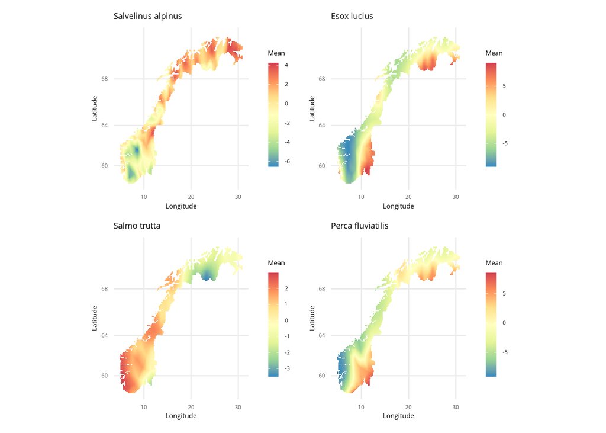

```r
plot_list <- list()
for(fish in fishes) {
  plot_list[[fish]] <- plot_species(
    predictions = readRDS(paste0("results/sharedfield_", fish, ".rds")),
    species = fish,
    plot_preferences = plot_preferences
  )
}

#plot_list[[1]]
patchwork::wrap_plots(plot_list, ncol = 2)
```

```r
ggsave("figures/fishplot_four_species.pdf", width = 7, height = 7)
```

And finally we predict and plot the bias field, which is shared between all the fish, as it describes the human sampling more than the distribution of the fish.

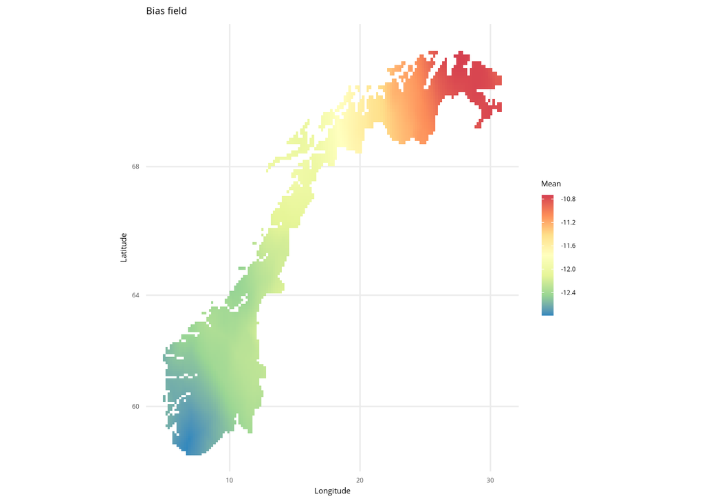

```r
# Predict biasfield
fish_biasfield <- predict(fish_model,
                          mesh = mesh,
                          mask = norway.poly,
                          format = 'sp',
                          biasfield = TRUE,
                          fun = 'linear',
                          n.samples = 1000) # Should "spatial" be false here?

saveRDS(fish_biasfield, "results/fish_biasfield.rds")
fish_biasfield <- readRDS("results/fish_biasfield.rds")

# Plot biasfield
ggplot() +
  gg(fish_biasfield$biasFields$artsobs) +
  labs(title = "Bias field") +
  plot_preferences
```

```r
ggsave("figures/fishplot_biasfield.pdf", width = 7, height = 7)
```

This document took 1.09 hours to compile.